# Multi Pathogen Dynamics - Documentation

## Overview

This app allows you to explore a model with 2 types of pathogens which can serially or simultaneously infect the hosts. Only one type of host is included. Read about the model in the “Model” tab. Then do the tasks described in the “What to do” tab.

This app assumes that you have worked through several of the previous ones, at least those in the *Basics* and *Reproductive Number* sections.

### Learning Objectives

- Understand how multiple pathogens can interact to impact ID dynamics

## The Model

### Model Overview

This model tracks susceptible hosts, hosts infected with either pathogen 1, pathogen 2 or both, and individuals recovered from infection with pathogen 1, pathogen 2 or both. As usual, infected hosts are assumed to be infectious.

The following compartments are included:

- **S** - uninfected and susceptible individuals.
- **I<sub>1</sub>** - individuals who are infected with pathogen 1.
- **I<sub>2</sub>** - individuals who are infected with pathogen 2.
- **I<sub>12</sub>** - individuals who are infected with both pathogen 1 and 2.
- **R<sub>1</sub>** - individuals recovered from infection with pathogen 1, still susceptible to pathogen 2.
- **R<sub>2</sub>** - individuals recovered from infection with pathogen 2, still susceptible to pathogen 1.
- **I<sub>1X</sub>** - individuals previously infected with pathogen 2 and now infected with pathogen 1.
- **I<sub>2X</sub>** - individuals previously infected with pathogen 1 and now infected with pathogen 2.
- **R<sub>12</sub>** - individuals recovered from infection with both pathogen 1 and 2.

The included processes/mechanisms are the following:

- Susceptible individuals can become infected with either pathogen 1 or 2 at rates *b<sub>1</sub>* and *b<sub>2</sub>*. They can also be exposed to doubly-infected individuals and become infected at rate *b<sub>12</sub>*, with a fraction *a* of individuals becoming infected with pathogen 1, the remainder, *1-a* will be infected with pathogen 2. Simultaneous double infection is assumed to not occur.
- Hosts infected with a single pathogen recover after some time at rates *g<sub>1</sub>* and *g<sub>2</sub>* and enter stages *R<sub>1</sub>* and *R<sub>2</sub>*. Alternatively, those hosts can become infected with the other pathogen and end up in the double-infected compartment, *I<sub>12</sub>*.
- Recovered individuals are immune to reinfection by the pathogen they have already been infected with (either at the same time or consecutively) but can still be infected with the pathogen they have not yet been infected with.
- Hosts recovered from one infection can become infected with the other pathogen and enter compartments *I<sub>1X</sub>* or *I<sub>2X</sub>*. Those hosts recover at the same rate as those who had no prior infection.
- All hosts who were infected with both pathogens, either serially or at the same time, eventually enter the double-recovered compartment *R<sub>12</sub>*.
- For simplicity, we assume that the rates at which hosts can become infected are independent of the status of the host that becomes infected. That means that hosts in the *S*, *I<sub>1</sub>* or *R<sub>1</sub>* compartments can become infected at the same rate *b<sub>2</sub>* with pathogen 2, independent of their infection history with pathogen 1, and the same holds for in reverse.

The biological meaning of the assumptions made here is that there is no immunological interaction between pathogens. One could alter the model to allow for this, e.g. to include short-term immunological cross-protection or similar features.

### Model Implementation

The flow diagram and the set of differential equations for the mathematical model implemented in this app are as follows:

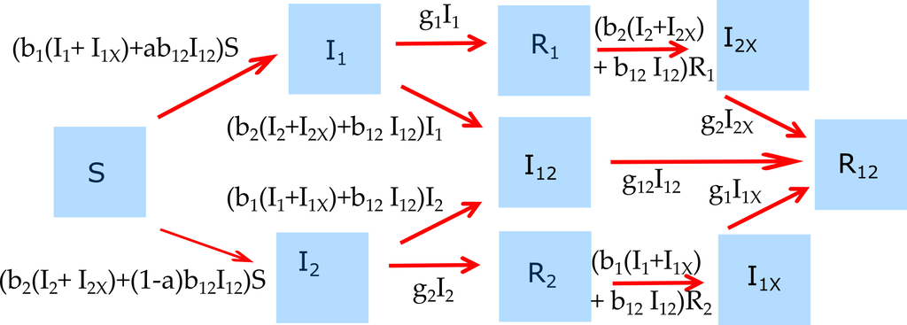

Flow diagram for this model.

$$\dot S = - (b_{1} (I_1+I_{1X}) + b_{2}
(I_2+I_{2X}) + b_{12}I_{12}) S$$
$$\dot I_1 = (b_{1} (I_1+I_{1X}) + ab_{12}
I_{12})S - (g_1 + b_{2} (I_2+I_{2X}) + b_{12} I_{12}) I_1$$
$$\dot I_2 = (b_{2} (I_2+I_{2X}) + (1-a)
b_{12} I_{12})S - (g_2 + b_{1}(I_1 + I_{1X}) + b_{12} I_{12})
I_2$$
$$\dot I_{12} = (b_{2}
(I_2+I_{2X}) + b_{12} I_{12}) I_1 + (b_{1}(I_1 + I_{1X}) + b_{12}
I_{12}) I_2 - g_{12} I_{12}$$
$$\dot
R_1 = g_1 I_1 - (b_2 (I_2 + I_{2X}) + b_{12} I_{12}) R_1$$
$$\dot R_2 = g_2 I_2 - (b_1 (I_1 + I_{1X}) +
b_{12} I_{12}) R_2$$
$$\dot I_{1X} =
(b_1 (I_1 + I_{1X}) + b_{12} I_{12}) R_2 - g_{1} I_{1X}$$
$$\dot I_{2X} = (b_2 (I_2 + I_{2X}) +
b_{12} I_{12}) R_1 - g_{2} I_{2X}$$
$$\dot R_{12} = g_{1} I_{1X} + g_{2} I_{2X} +
g_{12} I_{12}$$

## What to do

**The tasks below are described in a way that assumes everything is in units of DAYS (rate parameters, therefore, have units of inverse days). If any quantity is not given in those units, you need to convert it first (e.g. if it says a week, you need to convert it to 7 days).**

### Task 1

Set the initial number of infected with pathogen 1 to *I<sub>1</sub>* = 1, all other infected at zero. Susceptibles at 1000. Set all transmission rates to 0.001, all recovery rates at 0.5. Set fraction of pathogen 1 infections to *a=0.5*. Run the simulation for 100 days. Check that you only get a single outbreak with pathogen 1, with a peak of around 154 infected. Now set initial number of infected with pathogen 1 to 0, with pathogen 2 to 1. Run the simulation and check that you get exactly the same size outbreak with pathogen 2. The number susceptible left at the end of each outbreak is the same. This finding should not surprise you: In the presence of only a single pathogen, you can only get an outbreak caused by that pathogen. For both pathogens to infect hosts, both need to be present.

**Record**

- Number susceptible left at end of simulation

### Task 2

Leave everything as before but now start with 1 infected for both pathogen 1 and 2. You should see outbreaks for both pathogens with the same dynamics (in fact, you won’t see the curves for *I<sub>1</sub>*, *R<sub>1</sub>*, etc. since they are covered by the curves for *I<sub>2</sub>*, *R<sub>2</sub>*.) If you compare the peak number of infected for either *I<sub>1</sub>* or *I<sub>2</sub>* to the value you found in the previous task, you will notice it is lower (around 80). The two pathogens are competing for susceptible hosts, thus neither can cause quite as big an outbreak when both pathogens are present than when only one of them is present. However, the 2 outbreaks together lead to more total infections, which you can confirm by looking at the final number of susceptible and comparing to the previous task.

**Record**

- Number susceptible left at end of simulation

### Task 3

It basically never the case that two pathogens are the same in their transmission rates, recovery rates, starting values, etc. Let’s mimic a more realistic scenario by adjusting the settings for pathogen 1. Double *b<sub>1</sub>* to 0.002, keep the remaining parameters as before. Now pathogen 1 is twice as tranmissible as pathogen 2, thus we should expect it to dominate. Run the simulation and look at the peak infected for pathogen 1 and 2 to confirm that this is the case. As you have encountered many times previously, things are not linear, i.e. the fact that pathogen 1 is twice as transmissible than pathogen 2 does not lead to a peak for pathogen 1 that is twice as large as that for pathogen 1, in fact the difference is much larger, almost 100-fold and pathogen 1 completely dominates.

**Record**

- Maximum number infected with pathogen 1
- Maximum number infected with pathogen 2

### Task 4

Now also double the rate of recovery for pathogen 1 to *g<sub>1</sub>* = 1. Recall that in this simple SIR model, for just a single pathogen *i* (if the other one isn’t present) the reproductive number is *S<sub>0</sub>b<sub>i</sub>*/*g<sub>i</sub>*. This means that pathogen 1 and 2 have now the same reproductive number (pathogen 1 has both a doubled transmission and recovery rate.) Given that they have the same reproductive number, do you expect to see outbreaks for the two pathogens of the same size? Once you contemplated what to expect, check by running the simulation.

**Record**

- Maximum number infected with pathogen 1
- Maximum number infected with pathogen 2

### Task 5

You should have found in the previous task that despite the same reproductive number values, pathogen 1 causes a larger outbreak. If this is confusing, recall that *R<sub>0</sub>* says nothing about the speed of spread of a pathogen, only its infectiousness (how many new infections are produced by one infected host). If there is competition for hosts, a pathogen that spreads faster (pathogen 1 here) is advantaged. If none of that sounds familiar, you might want to revisit the reproductive number apps. We can give pathogen 2 a bit of a boost by letting it start with more initial infected. Let’s see what that does. Set *I<sub>2</sub>* = 10, keep everything else the same. Run the simulation. You’ll find that the peaks for the infected for the 2 pathogens are getting closer. It’s like in a race where runner 1 is faster, but runner 2 gets to start a distance ahead of runner 1. The initial difference in starting distance, the speed of the 2 runners, and the length of the race all determine the overall result. Feel free to explore a bit more how different initial values and transmission/recovery rates affect the competition between the 2 pathogens.

**Record**

- Maximum number infected with pathogen 1
- Maximum number infected with pathogen 2

### Task 6

Next, we’ll allow for a difference between the 2 pathogens by assuming that if a host is double infected, they are more likely to transmit one of the pathogens to an uninfected host. Set all values as in task 1 (I<sub>1</sub> = I<sub>2</sub> = 1, all transmission rates 0.001, all recovery rates 0.5). Then set *a* = 0.9. This means that a double-infected host will mainly transmit pathogen 1 to other hosts. Thus we should expect pathogen 1 to have an advantage. Run the simulation to confirm this.

**Record**

- Maximum number infected with pathogen 1
- Maximum number infected with pathogen 2

### Task 7

Change the rate at which double infected hosts recover from 0.5 to *g<sub>12</sub>* = 5. Keep everything else unchanged. Run the simulation and look at the maximum for each pathogen. You will find that the values are much closer compared to the previous task. Can you figure out why? Think about the advantage that pathogen 1 has (all infections caused by double-infected hosts are with pathogen 1) and how that advantage is influenced as you increase the recovery rate *g<sub>12</sub>*.

**Record**

- Maximum number infected with pathogen 1
- Maximum number infected with pathogen 2

### Task 8

Keep exploring. For instance explore how the infection rate of double-infected hosts, *b<sub>12</sub>* affects the competition between the pathogens, and how that depends on other parameter settings. If you want, think of 2 real-world pathogens that might compete (e.g. influenza and RSV) and see if you can find parameter values that approximate those pathogens and their possible interactions. Multi-pathogen models can easily get complicated, and here we left out a good bit of possible interactions. If you want to dig deeper, you can get yourself the code for this app (see *Further Resources*) and modify it to allow for further processes and interactions between the pathogens.

**Record**

- Nothing

## Further Information

- This app (and all others) are structured such that the Shiny part (the graphical interface you see and the server-side function that goes with it) calls an underlying R script (or several) which runs the simulation for the model of interest and returns the results.
- For this app, the underlying function(s) running the simulation are called `simulate_multipathogen_ode`. You can call them directly, without going through the shiny app. Use the `help()` command for more information on how to use the functions directly. If you go that route, you need to use the results returned from this function and produce useful output (such as a plot) yourself.
- You can also download all simulator functions and modify them for your own purposes. Of course to modify these functions, you’ll need to do some coding.
- For examples on using the simulators directly and how to modify them, read the package vignette by typing `vignette('DSAIDE')` into the R console.